[O’Hara on GitHub](https://github.com/oharac)

# Rasterize EEZs, LMEs, and Bathymetry

Compiled on Tue Jun 5 16:03:22 2018 by ohara

```r
knitr::opts_chunk$set(fig.width = 6, fig.height = 4, fig.path = 'Figs/',
                      echo = TRUE, message = FALSE, warning = FALSE)

library(raster)
library(sf)
source('https://raw.githubusercontent.com/oharac/src/master/R/common.R')


dir_git <- '~/github/spp_health_dists'
dir_o_anx <- file.path(dir_O, 'git-annex/spp_health_dists')

### goal specific folders and info
dir_check   <- file.path(dir_git, 'data/iucn/map_check')

dir_shp <- file.path(dir_M, 'git-annex/globalprep/_raw_data/iucn_spp/d2017-3')

### provenance tracking
library(provRmd); prov_setup()
```

# 1 Summary

Set up analysis rasters for EEZs, LMEs, and bathymetry at a 0.1° lat-long resolution.

# 2 Methods

## 2.1 EEZ raster

Using the OHI global EEZ shapefile, we will include all EEZs by OHI region code, as well as FAO regions and Antarctica, using unique identifiers. This will allow for separation by high seas vs. EEZ, or different takes on IUCN regional assessments using FAO or EEZ identifiers.

```r
eez_rast_file <- file.path(dir_o_anx, 'spatial', 'eez_rast_010_wgs84.tif')


eez_shp <- st_read(file.path(dir_M, 'git-annex/globalprep/spatial/v2017/regions_2017_update.shp'))
```

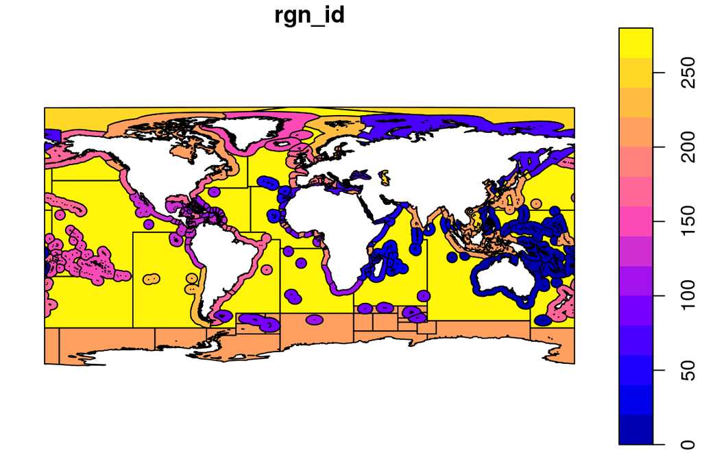

```r
eez_df <- eez_shp %>%
  as.data.frame() %>%
  dplyr::select(-geometry)
eez_ids <- eez_df %>%
  select(rgn_id, rgn_name, rgn_ant_id) %>%
  distinct()
### rgn_ant_id is same as rgn_id except for Antarctica.  We don't really
### need to chunk out Antarctica at this point so just use rgn_id.
### Filter out all land polygons and project back to WGS84 (4326) since
### this shapefile is in Mollweide.

eez_shp_reclass <- eez_shp %>%
  # mutate(rgn_id_reclass = ifelse(str_detect(rgn_type, '^land'), 0, rgn_id)) %>%
  filter(!str_detect(rgn_type, '^land')) %>%
  select(rgn_id, geometry) %>%
  st_transform(4326)

plot(eez_shp_reclass)
```

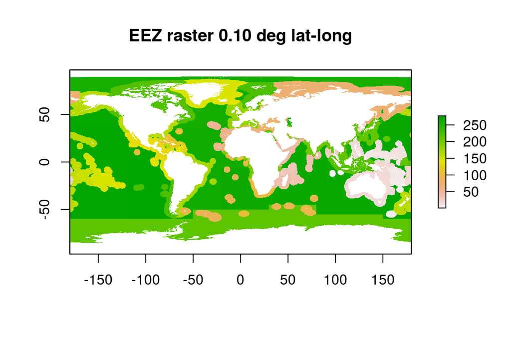

```r
rast_base_tenthdeg <- raster::raster(resolution = .10,
                                     ext = extent(c(-180, 180, -90, 90)))

eez_rast <- fasterize::fasterize(eez_shp_reclass, rast_base_tenthdeg,
                                 field = 'rgn_id', fun = 'min')

plot(eez_rast, main = 'EEZ raster 0.10 deg lat-long')
```

```r
writeRaster(eez_rast, eez_rast_file, overwrite = TRUE)
```

### 2.1.1 Also create area raster

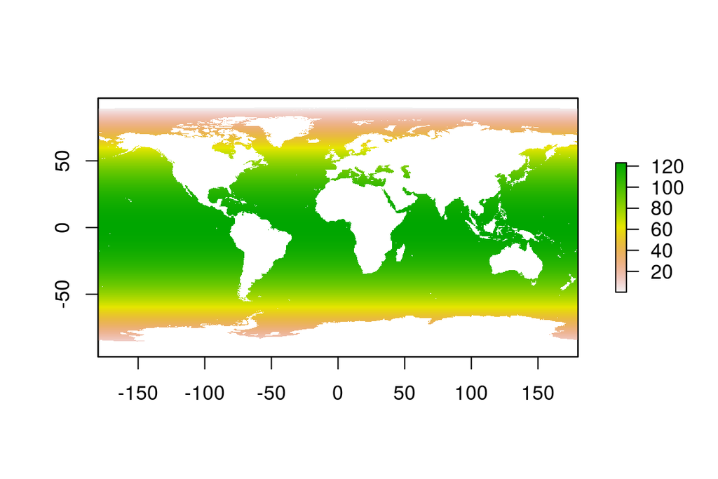

```r
area_rast_file <- file.path(dir_o_anx, 'spatial', 'area_rast_010_wgs84.tif')

eez_rast <- raster(eez_rast_file)

area_rast <- raster::area(eez_rast)

values(area_rast)[is.na(values(eez_rast))] <- NA

plot(area_rast)
```

```r
writeRaster(area_rast, area_rast_file, overwrite = TRUE)
```

## 2.2 LME raster

Using the LME shapefile, we will include all MLEs and then mask out land using the EEZ raster (for consistency).

```r
lme_rast_file <- file.path(dir_o_anx, 'spatial', 'lme_rast_010_wgs84.tif')


lme_shp <- st_read(file.path(dir_o_anx, 'lme/LME66', 'LMEs66.shp'))
```

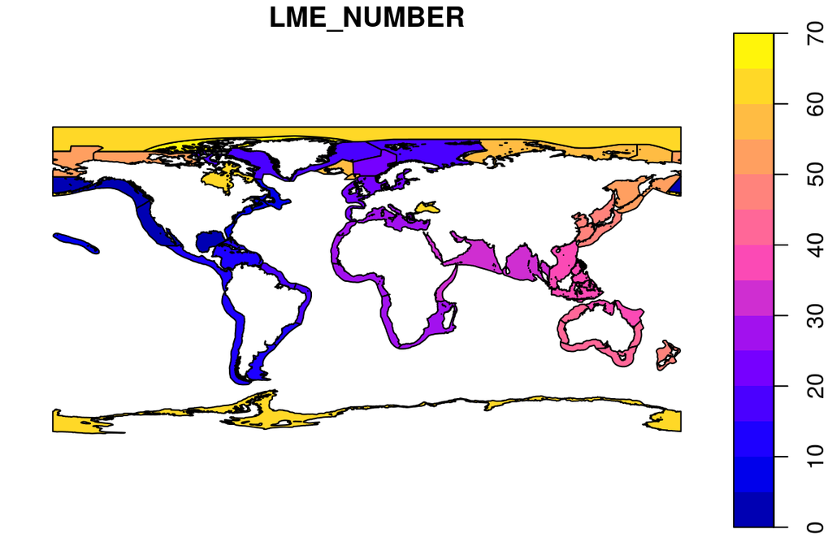

```r
lme_shp_reclass <- lme_shp %>%
  select(LME_NUMBER, geometry) %>%
  st_transform(4326)

plot(lme_shp_reclass)
```

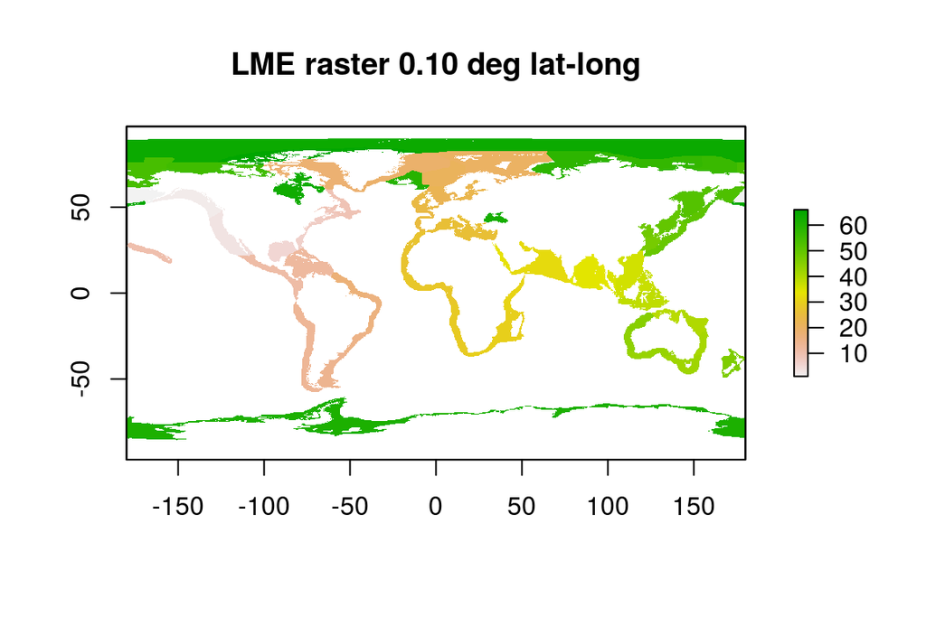

```r
rast_base_tenthdeg <- raster::raster(resolution = .10,
                                     ext = extent(c(-180, 180, -90, 90)))

lme_rast <- fasterize::fasterize(lme_shp_reclass, rast_base_tenthdeg,
                                 field = 'LME_NUMBER', fun = 'min')

lme_rast[is.na(eez_rast)] <- NA
plot(lme_rast, main = 'LME raster 0.10 deg lat-long')
```

```r
### check whether there are shoreline gaps between LME maps and EEZ maps
# x <- eez_rast
# x[!is.na(values(lme_rast))] <- NA
# plot(x)
### small artifacts around the edges... not enough to worry about?

writeRaster(lme_rast, lme_rast_file, overwrite = TRUE)
```

## 2.3 Bathymetry raster

Using [General Bathymetric Chart of the Oceans (GEBCO) bathymetry raster](https://www.bodc.ac.uk/data/hosted_data_systems/gebco_gridded_bathymetry_data/), identify min depth of ocean cells. Leaving as min depth allows for changing depth thresholds if desired.

NOTE: 1 arcmin and 30 arcsec are available; 30 arcsec is more recent but one arcmin should be sufficient for our purposes. Resample to 6 arc-minute (0.10°) using min depth in each cell.

### 2.3.1 Create and view minimum depth raster

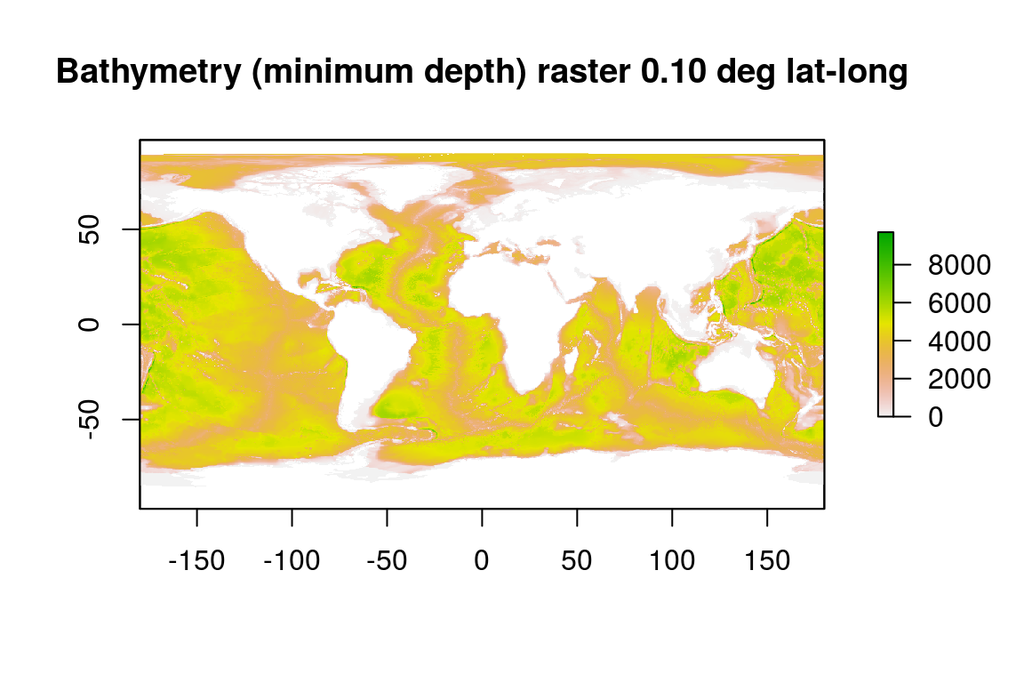

```r
bathy_rast_file <- file.path(dir_o_anx, 'spatial', 'bathy_rast_010_wgs84.tif')

gebco_rast_file <- file.path(dir_o_anx, 'gebco', 'GRIDONE_1D.nc')
gebco_rast_raw  <- raster(gebco_rast_file)

if(!file.exists(bathy_rast_file)) {
  ### The GEBCO raster is elevation, so depth is neg... for min depth,
  ### aggregate by max (and vice versa)
  bathy_rast_min <- gebco_rast_raw %>%
    raster::aggregate(fact = 6, fun = max)

  bathy_rast_min <- -1 * bathy_rast_min

  rast_base_tenthdeg <- raster::raster(resolution = .10,
                                       ext = extent(c(-180, 180, -90, 90)))

  bathy_rast <- bathy_rast_min %>%
    raster::resample(rast_base_tenthdeg, method = 'ngb')

  values(bathy_rast)[is.na(values(eez_rast))] <- NA
  values(bathy_rast)[values(bathy_rast) < 0] <- 0
  plot(bathy_rast, main = 'Bathymetry (minimum depth) raster 0.10 deg lat-long')

  ### check whether there are shoreline gaps between LME maps and EEZ maps
  # x <- eez_rast
  # x[!is.na(values(lme_rast))] <- NA
  # plot(x)
  ### small artifacts around the edges... not enough to worry about?

  writeRaster(bathy_rast, bathy_rast_file, overwrite = TRUE)
} else {
  git_prov(bathy_rast_file, 'output')
  plot(raster(bathy_rast_file), main = 'Bathymetry (minimum depth) raster 0.10 deg lat-long')
}
```

### 2.3.2 Viewing categories: 0-60, 60-200, 200+ m depths

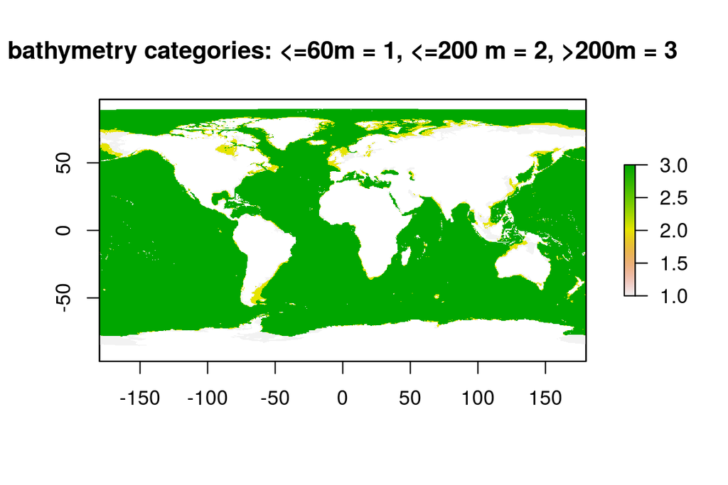

```r
bathy_rast <- raster(bathy_rast_file)
bathy_rast_cats <- raster(bathy_rast_file)

values(bathy_rast_cats)[values(bathy_rast)  >= 0] <- 1
values(bathy_rast_cats)[values(bathy_rast)  > 60] <- 2
values(bathy_rast_cats)[values(bathy_rast) > 200] <- 3

plot(bathy_rast_cats, main = 'bathymetry categories: <=60m = 1, <=200 m = 2, >200m = 3')
```

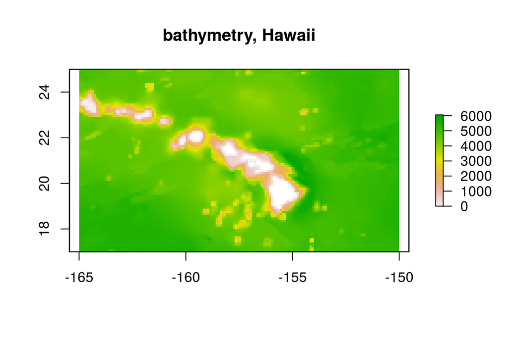

```r
y <- bathy_rast %>%
  crop(extent(c(-165, -150, 17, 25)))
plot(y, main = 'bathymetry, Hawaii')
```

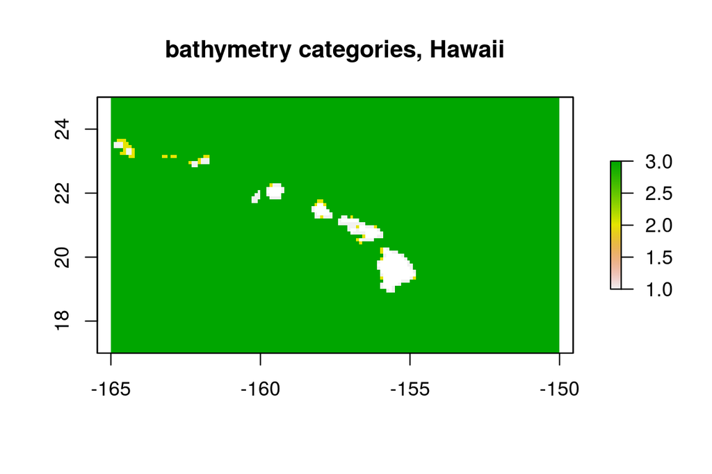

```r
x <- bathy_rast_cats %>%
  crop(extent(c(-165, -150, 17, 25)))
plot(x, main = 'bathymetry categories, Hawaii')
```

```r
prov_wrapup(commit_outputs = FALSE)
```

# 3 Provenance

- *Run ID: 2 (7b301ed); run tag: “standard run”*
- *Run elapsed time: 72.1 seconds; run memory usage: 13091.6 MB*
- *System info:*
  - *System: Linux, Release: 4.4.0-112-generic. Machine: x86_64. User: ohara.*
  - *R version: R version 3.4.4 (2018-03-15), Platform: x86_64-pc-linux-gnu, Running under: Ubuntu 14.04.5 LTS.*
  - *Attached base packages: stats, graphics, grDevices, utils, datasets, methods, base*
  - *Other attached packages: bindrcpp_0.2, provRmd_0.1.1, stringr_1.2.0, RColorBrewer_1.1-2, dplyr_0.7.2, purrr_0.2.3, readr_1.1.0, tidyr_0.7.0, tibble_1.3.4, ggplot2_2.2.1.9000, tidyverse_1.1.1, sf_0.6-1, raster_2.5-8, sp_1.2-5*

[figure not shown]

| sequence | file_name | parent_chunk | file_dir | filetype | uncomm_chgs | commit_hash_short |
| --- | --- | --- | --- | --- | --- | --- |
| 0 | 4_rasterize_eez_lme.Rmd | prov_footer | ~/github/spp_health_dists/data_setup | parent_script |  |  |
| 0 | 4_rasterize_eez_lme.Rmd#create_cell_area_raster | create_cell_area_raster | ~/github/spp_health_dists/data_setup | parent_chunk |  |  |
| 0 | 4_rasterize_eez_lme.Rmd#plot_bathy_raster_categories | plot_bathy_raster_categories | ~/github/spp_health_dists/data_setup | parent_chunk |  |  |
| 0 | 4_rasterize_eez_lme.Rmd#prov_footer | prov_footer | ~/github/spp_health_dists/data_setup | parent_chunk |  |  |
| 0 | 4_rasterize_eez_lme.Rmd#set_up_bathymetry_raster | set_up_bathymetry_raster | ~/github/spp_health_dists/data_setup | parent_chunk |  |  |
| 0 | 4_rasterize_eez_lme.Rmd#set_up_EEZ_raster | set_up_EEZ_raster | ~/github/spp_health_dists/data_setup | parent_chunk |  |  |
| 0 | 4_rasterize_eez_lme.Rmd#set_up_LME_raster | set_up_LME_raster | ~/github/spp_health_dists/data_setup | parent_chunk |  |  |
| 1 | eez_rast_010_wgs84.tif | set_up_EEZ_raster | ~/git-annex/spp_health_dists/spatial | output |  |  |
| 2 | eez_rast_010_wgs84.tif | create_cell_area_raster | ~/git-annex/spp_health_dists/spatial | input |  |  |
| 3 | area_rast_010_wgs84.tif | create_cell_area_raster | ~/git-annex/spp_health_dists/spatial | output |  |  |

[output cut: 6 more lines]